# pml-project-LuciaYang

Lucia Yang

Saturday, May 23, 2015

In order to predict classe variable, the first step is to understand the data. Certain variables may have little predictive power. I exclude columns with more than half of the missing values, and I exclude columns of user names, time stamps and new window indicator. There are 52 covariates left.

```r
setwd("H:/others/Practical Machine Learning/Project")
library("caret")
library("pls")
library("Hmisc")
library("rattle")
######-------------------------Data Prepare--------------------------------#####
trainData = read.table("pml-training.csv",na.strings=c("NA",""),
               header = T,nrows = -1,fill=TRUE,sep=",",strip.white = T,
               as.is=T,row.names = NULL,check.names=FALSE )
#19622*160
testData = read.table("pml-testing.csv",na.strings=c("NA",""),
                       header = T,nrows = -1,fill=TRUE,sep=",",strip.white = T,
                       as.is=T,row.names = NULL, check.names=FALSE )
#20*160

#If there are more than 50% NAs in one value, do not include that variable
trainDataSub = trainData[,(colMeans(is.na(trainData)) <0.5)]
dim(trainDataSub)
```

```
## [1] 19622    60
```

```r
#[1] 19622    60


uniqueV = sapply(trainDataSub,function(x) length(unique(x)))
dubiousX = names(uniqueV[uniqueV<5])
dubiousX
```

```
## [1] "new_window"
```

```r
# new_window

notNo = sapply(trainDataSub,function(x) is.numeric(x))
notNumeric = names(notNo[notNo == FALSE])
notNumeric
```

```
## [1] "user_name"      "cvtd_timestamp" "new_window"     "classe"
```

```r
# "user_name"      "cvtd_timestamp" "new_window"     "classe"
unique(trainDataSub[,"new_window"])
```

```
## [1] "no"  "yes"
```

```r
#no yes

trainDataSub = trainDataSub[,-which(names(trainDataSub) %in% c("user_name","cvtd_timestamp","new_window"))]
dim(trainDataSub)
```

```
## [1] 19622    57
```

```r
#19622 57

table(trainDataSub$classe)
```

```
##
##    A    B    C    D    E
## 5580 3797 3422 3216 3607
```

```r
# A    B    C    D    E
# 5580 3797 3422 3216 3607

#delete the var for row numbers
trainDataSub = trainDataSub[,-which(colnames(trainDataSub) %in% c("","raw_timestamp_part_1","raw_timestamp_part_2","num_window"))]
```

I build tree model, treebag model, random forest model and gbm model. Firstly, using tree model building as an example. I divide the cleaned pml-training data into 10-fold so that I could use 10-fold cross validation. It is done through “trainControl” function. Then I build the model using “train” function with “rpart” method in caret package.

```r
trainDataSub$classe = as.factor(trainDataSub$classe)
load("H:/others/Practical Machine Learning/Project/modFit1.RData")
# ctrl = trainControl(method = "cv",number = 10)
# modFit1 = train(classe ~ .,method="rpart",data = trainDataSub,trControl = ctrl)
varImp(modFit1)
```

```
## rpart variable importance
##
##   only 20 most important variables shown (out of 52)
##
##                      Overall
## pitch_forearm         100.00
## roll_forearm           72.97
## roll_belt              70.36
## magnet_dumbbell_y      49.51
## accel_belt_z           43.02
## magnet_belt_y          40.80
## yaw_belt               40.41
## magnet_dumbbell_z      36.37
## total_accel_belt       35.34
## magnet_arm_x           27.09
## accel_arm_x            26.33
## roll_dumbbell          18.67
## accel_dumbbell_y       15.60
## roll_arm               15.28
## magnet_belt_z           0.00
## gyros_belt_y            0.00
## accel_dumbbell_x        0.00
## total_accel_arm         0.00
## magnet_forearm_y        0.00
## total_accel_dumbbell    0.00
```

```r
# save(modFit1,file = "modFit1.RData")
predict(modFit1,newdata = testData)
```

```
##  [1] C A C A A C C A A A C C C A C A A A A C
## Levels: A B C D E
```

The final model is shown in below graph.

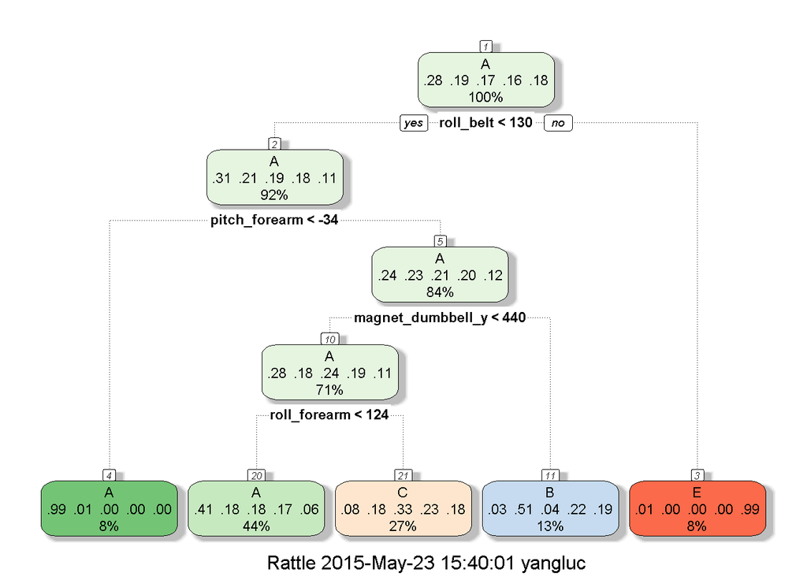

The accuracy(1-out-of-sample error) is not impressive with this model as shown in the below cross validation results. Almost half of the predictions are likely to be wrong.

```r
modFit1$resample
```

```
##     Accuracy     Kappa Resample
## 1  0.5165563 0.3682306   Fold02
## 2  0.5178389 0.3705311   Fold01
## 3  0.4959225 0.3388790   Fold03
## 4  0.4915859 0.3358560   Fold06
## 5  0.4882773 0.3313197   Fold05
## 6  0.4949032 0.3399763   Fold04
## 7  0.5124936 0.3642522   Fold07
## 8  0.5224261 0.3776729   Fold10
## 9  0.5330957 0.3921132   Fold09
## 10 0.4905756 0.3343398   Fold08
```

After the tree model, I build treebag model. I also use 10-fold cross validation. The results are shown below.

```r
######-------------------------Model_treebag--------------------------------#####
load("H:/others/Practical Machine Learning/Project/modFit2.RData")
# ctrl = trainControl(method = "cv",number = 10)
# modFit2 = train(classe ~ .,method="treebag",data = trainDataSub,trControl = ctrl)
# modFit2
# modFit2$results
modFit2$finalModel
```

```
##
## Bagging classification trees with 25 bootstrap replications
```

```r
# save(modFit2,file = "modFit2.RData")

varImp(modFit2)
```

```
## treebag variable importance
##
##   only 20 most important variables shown (out of 52)
##
##                   Overall
## roll_belt          100.00
## yaw_belt            83.90
## pitch_belt          78.72
## pitch_forearm       72.72
## roll_forearm        64.05
## magnet_dumbbell_z   58.54
## magnet_dumbbell_y   58.20
## accel_dumbbell_y    53.02
## roll_dumbbell       38.65
## magnet_belt_y       35.75
## accel_belt_z        35.25
## yaw_arm             32.56
## magnet_belt_z       31.40
## magnet_dumbbell_x   30.52
## accel_forearm_x     29.48
## magnet_forearm_z    27.88
## accel_dumbbell_z    26.29
## gyros_belt_z        26.16
## accel_arm_x         22.51
## total_accel_belt    22.28
```

The out-of-sample error is much smaller, around 1-2%.

```r
modFit2$resample
```

```
##     Accuracy     Kappa Resample
## 1  0.9806320 0.9754965   Fold01
## 2  0.9836901 0.9793638   Fold02
## 3  0.9908304 0.9884009   Fold03
## 4  0.9882773 0.9851719   Fold04
## 5  0.9831804 0.9787203   Fold05
## 6  0.9913398 0.9890466   Fold06
## 7  0.9903111 0.9877431   Fold07
## 8  0.9903209 0.9877556   Fold08
## 9  0.9857288 0.9819452   Fold09
## 10 0.9882773 0.9851691   Fold10
```

Then I further build random forest and gbm models. I use 2-fold cross validation for these two models.

```r
# ctrl = trainControl(method = "cv",number = 2)
# modFit3 = train(classe ~ .,method="rf",data = trainDataSub,trControl = ctrl,prox = TRUE)
# save(modFit3,file = "modFit3.RData")
load("H:\\others\\Practical Machine Learning\\Project\\modFit3.RData")
# modFit3$finalModel

# ctrl = trainControl(method = "cv",number = 2)
# modFit4 = train(classe ~ .,method="gbm",data = trainDataSub,trControl = ctrl,verbose=FALSE)
# save(modFit4,file = "modFit4.RData")
load("H:\\others\\Practical Machine Learning\\Project\\modFit4.RData")
# modFit4$finalModel
```

Random forest model cross validation results are shown below.

```r
modFit3$resample
```

```
##    Accuracy     Kappa Resample
## 1 0.9926613 0.9907166    Fold1
## 2 0.9887881 0.9858171    Fold2
```

Gbm model cross validation results are as follows.

```r
modFit4$resample
```

```
##    Accuracy     Kappa Resample
## 1 0.9625892 0.9526660    Fold1
## 2 0.9596413 0.9489313    Fold2
```

Random forest model achieves less than 1.2% error and gbm model achieves less than 5% error. From the cross validation performance, random forest model and treebag model are the best. It is dangerous that the model can be over fitting if we do not perform enough out-of-sample test. Treebag model is selected in the end due to more extensive testing it goes through, and it is not as computational intensive as random forest model. The predicted values for the 20 test cases are below.

```r
predict(modFit2,newdata = testData)
```

```
##  [1] B A B A A E D B A A B C B A E E A B B B
## Levels: A B C D E
```